# Migration Experiment_01-Data-Exploration

# I. Setup

## I.A. Libraries and Load Data

## I.B. Useful Reference Values

```r
# Metadata
num_checklists = n_distinct(checklists_EXP$Checklist.ID)
num_pairs = n_distinct(checklists_EXP$Date)
obs_dates = unique(checklists_EXP$Day)


# List of Species
species_order <- my_tax_EXP %>% arrange(Taxonomy) %>% pull(Species)
num_species = length(species_order)
```

## I.D. Add Population column

```r
myebird_EXP <- myebird_EXP %>% group_by(Date, Species) %>%
    mutate(Population = max(Count), .after = Count) %>% ungroup()
```

## I.E. Add Species Groups to myebird_EXP; Make Species and Groups factors

```r
# Add Species Groups to myebird_EXP
my_tax_EXP_join <- my_tax_EXP %>% select(Species, Species.Group)

myebird_EXP <- left_join(myebird_EXP, my_tax_EXP_join, by = "Species") %>%
  relocate(Species.Group, .after = Species)

# make Species and Groups factors
#... for myebird_EXP
myebird_EXP <- myebird_EXP %>% mutate(
  Species = factor(Species, levels = my_tax_EXP$Species),
  Species.Group = factor(Species.Group, levels = unique(my_tax_EXP$Species.Group)))
#... and for mytaxonomy
my_tax_EXP <- my_tax_EXP %>% mutate(
  Species = factor(Species, levels = my_tax_EXP$Species),
  Species.Group = factor(Species.Group, levels = unique(my_tax_EXP$Species.Group)))
```

## I.F. Functions

```r
# ---- # MY FILTER FUNCTION ----
# - "keep": can select character vectors and/or specific species strings to keep
#        - eg keep = c(vec1, "species1")
# - "group": associated with "Species.Group", which is a grouping of convenience for graphing, NOT a precise phylogenetic grouping
# - "complete" and "paired" : pass TRUE/FALSE to function, if statement clears only if TRUE is passed, THEN filter is applied.
#        - This shouldn't be necessary since dataframes are already segregated (myebird_EXP, myebird_EXP_extra_obs)
# - this function uses "my_tax_EXP" dataframe defined in setup chunk, outside of this function

my_filter <- function(df,
                      complete = NULL, paired = NULL,
                      keep = NULL, drop = NULL,
                      group_keep = NULL, group_drop = NULL,
                      time_bin_keep = NULL,
                      date_drop = NULL) {


  # Fold group_keep into keep
  if(!is.null(group_keep)) {
    group_sp <- my_tax_EXP %>% filter(Species.Group %in% group_keep) %>% pull(Species) %>% as.character()
    keep = c(keep, group_sp) }

  # Fold group_drop into drop
  if (!is.null(group_drop)) {
    group_sp <- my_tax_EXP %>% filter(Species.Group %in% group_drop) %>% pull(Species) %>% as.character()
    drop = c(drop, group_sp) }


  # Save "df" argument as "result" so that it has a different name after all the filtering
  result <- df

  if(!is.null(complete))                result <- filter(result, Is.Complete == complete)
  if(!is.null(paired))                  result <- filter(result, Is.Paired == paired)
  if(!is.null(keep))          result <- filter(result, Species %in% keep)
  if(!is.null(drop))          result <- filter(result, !(Species %in% drop))
  # don't actually need the parentheses for !(Species %in% drop), bc !Species doesn't make sense, but !Boolean does
  if(!is.null(time_bin_keep)) result <- filter(result, Start.Time.Bin %in% time_bin_keep)
  if(!is.null(date_drop))     result <- filter(result, !(Date %in% date_drop))

 # result <- result %>% group_by(Date, Species) %>%
  #  mutate(Population = max(Count), .after = Count) %>% ungroup()

  result
}
```

```r
# ---- 0. REGION POLYGON: needed as the default `region_poly` for
# get_expected_abundance() below. Suffolk County, MA is loaded once here,
# then reprojected to match the CRS used by eBird's abundance rasters
# (we load one raster, "yerwar", purely to read its CRS off of it).
suffolk <- counties(state = "MA", cb = TRUE, progress_bar = FALSE) %>%
  filter(NAME == "Suffolk")
```

```r
abd <- load_raster("yerwar", product = "abundance", resolution = "27km")

suffolk_v <- vect(suffolk)
suffolk_v <- project(suffolk_v, crs(abd))   # match raster's CRS


# DOWNLOAD SPECIES ABUNDANCE DATA AND MAKE 3-PART GRAPH

# ---- 1. FUNCTION DEFINITION: one species -> expected abundance curve ----
# manual overrides for species whose codes don't match my taxonomy df
code_overrides <- c(
  "Eastern Warbling Vireo" = "warvir",   # <- replace with what the search returns
  "Northern House Wren"    = "houwre"    # <- replace with what the search returns
)
get_expected_abundance <- function(species_common_name,
                                   taxonomy_df = my_tax_EXP,
                                   region_poly = suffolk_v,
                                   months_keep = c(3,4,5,6)) {
  code <- if (species_common_name %in% names(code_overrides)) {
    code_overrides[[species_common_name]]          # override wins if present
  } else {
    taxonomy_df %>% filter(Species == species_common_name) %>% pull(Species.Code)
  }
  # FIXED GUARD: catches NA, empty, and multi-match
  if (length(code) != 1 || is.na(code) || code == "") {
    warning("No usable species code for: ", species_common_name); return(NULL)
  }
  result <- try({
    ebirdst_download_status(species = code)
    load_raster(code, product = "abundance", resolution = "27km")
  }, silent = TRUE)
  if (inherits(result, "try-error")) {             # keeps one bad species from killing the whole run
    warning("Download/load failed for: ", species_common_name, " (", code, ")")
    return(NULL)
  }
  vals <- as.numeric(extract(result, region_poly, fun = mean, na.rm = TRUE)[1, -1])
  data.frame(Species = species_common_name,
             date = as.Date(names(result)),
             expected_abundance = vals) %>%
    filter(month(date) %in% months_keep) %>%
    mutate(yday = yday(date))
}


# ---- 2. FUNCTION DEFINITION: SHARED PLOT SETUP ----

# now a FUNCTION, since the x-range varies by species
align_layers <- function(rng) {
  list(
    geom_vline(xintercept = obs_yday, color = "grey65", linewidth = 0.3, linetype = "dotted"),
    annotate("rect", xmin = -Inf, xmax = min(obs_yday), ymin = -Inf, ymax = Inf,
             fill = "grey85", alpha = 0.4),
    annotate("rect", xmin = max(obs_yday), xmax = Inf, ymin = -Inf, ymax = Inf,
             fill = "grey85", alpha = 0.4),
    scale_x_continuous(breaks = month_breaks, labels = month_labels),
    coord_cartesian(xlim = rng)          # crops the view without dropping rows (no warnings)
  )
}

# ---- 3. FUNCTION DEFINITION: one species -> stacked 3-panel figure ----
make_3panel <- function(sp) {
  exp_sp <- expected_all %>% filter(Species == sp)
  if (nrow(exp_sp) == 0) return(NULL)              # skip species that failed lookup

  rng <- if (!is.null(range_overrides[[sp]])) range_overrides[[sp]] else default_range

  p1 <- ggplot(exp_sp, aes(x = yday, y = expected_abundance)) +
    geom_line() + geom_point() +
    align_layers(rng) +
    labs(title = sp, subtitle = "Expected regional abundance (eBird 2023 modeled estimate)", x = NULL, y = "Expected") +
    theme_minimal()


  p2 <- birdcast %>%
    ggplot(aes(x = yday, y = Average.Birds.in.Flight)) +
    geom_line() + geom_point() +
    align_layers(rng) +
    labs(subtitle = "BirdCast migration", x = NULL, y = "Birds in flight") +
    theme_linedraw()


  p3 <- myebird_EXP %>% filter(Species == sp) %>%
    mutate(yday = yday(Date)) %>%
    ggplot(aes(x = yday, y = Population)) +
    geom_line(linetype = "dashed", color = "grey50", linewidth = 0.4) +
    geom_point(size = 2) +
    geom_rug(sides = "b", length = unit(0.04, "npc")) +
    align_layers(rng) +
    labs(subtitle = "Your observed counts (dashed = interpolated between visits)",
         x = NULL, y = "Count") +
    theme_minimal()

  p1 / p2 / p3
}
```

# II. Subdividing Datasets (DAY POPULATION, NO TIMEPOINT)

Let’s make some subgrouped dataframes with my filter function

Pass LONG FORM dataframes for graphing (heat maps at least)

## II. A. Migrants, Residents, Nonnative

```r
#### Tags ####
residents_sp <- my_tax_EXP %>% filter(Resident == TRUE) %>% pull(Species)
migrants_sp  <- my_tax_EXP %>% filter(Resident==FALSE) %>% pull(Species)
nonnative_sp <- c("European Starling","House Sparrow")

#### Datasets ####
# Selections will remove duplicate rows
residents    <- my_filter(df = myebird_EXP, keep = residents_sp)  %>%
  select(-"Count") %>% distinct(Date, Species, .keep_all=TRUE)

migrants     <- my_filter(df = myebird_EXP, keep = migrants_sp)  %>%
  select(-"Count") %>% distinct(Date, Species, .keep_all=TRUE)
```

## II. B. Warblers: Datasets and Tags

```r
warblers    <- my_filter(df = myebird_EXP, group_keep = c("Warblers"))  %>%
    select(-"Count") %>% distinct(Date, Species, .keep_all=TRUE)

warblers_sp <- warblers %>% distinct(Species) %>% pull(Species) %>% as.character()
```

## II. D. Favorite Species - Datasets and Tags

### II.D.1. Favorite Species - Large List

```r
favorites <- my_filter(myebird_EXP, drop = c("Mourning Dove", "Turkey Vulture", "Northern Mockingbird", "American Goldfinch", "Brown-headed Cowbird", "Common Grackle", "Northern Cardinal", "European Starling", "American Robin"), group_drop = c("Cormorants", "Corvids"))
favorites_sp <- favorites %>% distinct(Species) %>% pull(Species) %>% as.character()

# favorites_sp narrowed to migratory (non-resident) species only. Computed
# here (instead of down in the wave-delta section where it's also used) so
# the richness calculation below can use it too.
favorites_nonresident_sp <- favorites_sp[favorites_sp %in% as.character(migrants_sp)]
```

### II.D.3. Favorite Species - w Good Patterns

Specifically looking for clear patterns, multiple sightings, excluding boring birds (robins, mockingbirds)

```r
##### Dataset ###
good_patterns_sp <- c("Great Crested Flycatcher",
    "Eastern Warbling Vireo",
    "Northern House Wren",
    "Wood Thrush",
    "Cedar Waxwing",
    "Eastern Wood-Pewee",
    "Scarlet Tanager",
    "Red-eyed Vireo",
    "Indigo Bunting",
    "Chimney Swift",
    "Pine Warbler",
    "Black-and-white Warbler",
    "Ovenbird",
    "Northern Parula",
    "Yellow-rumped Warbler",
    "Black-throated Green Warbler",
    "Blackpoll Warbler",
    "American Redstart")

good_patterns <- my_filter(myebird_EXP, keep = c(good_patterns_sp)) %>%
  select(-"Count") %>% distinct(Date, Species, .keep_all=TRUE)

# Organizing Species order
good_patterns <- good_patterns %>%
  mutate(Species = factor(Species, levels = c(
    "Great Crested Flycatcher",
    "Eastern Warbling Vireo",
    "Northern House Wren",
    "Wood Thrush",
    "Cedar Waxwing",
    "Eastern Wood-Pewee",
    "Scarlet Tanager",
    "Red-eyed Vireo",
    "Indigo Bunting",
    "Chimney Swift",
    "Pine Warbler",
    "Black-and-white Warbler",
    "Ovenbird",
    "Northern Parula",
    "Yellow-rumped Warbler",
    "Black-throated Green Warbler",
    "Blackpoll Warbler",
    "American Redstart"
  )))
```

# III. Calculate Species Richness

## III.A. Make Richness Dataframes (wide version, each count gets its own column)

MAIN PURPOSE: Date -> # Unique Species

One row per day, so no time bins, species-specific counts/population

Will make different richness counts, based on different subsets of birds

- “All” richness = Tot.Sp
- “Favorites” richness = Tot.Sp.Faves = only counting from my “favorite” species list
- “Non-Resident Favorites” richness = Tot.Sp.Nonres.Faves
- “Warblers” richness = Tot.Sp.Warblers

```r
# 1. Start with richness Tot.Sp count for ALL birds
richness_by_day <- myebird_EXP %>% filter(Population>0) %>% group_by(Date) %>%
  mutate(Tot.Sp = n_distinct(Species)) %>% ungroup() %>%
  select(c(Date:Day, Tot.Sp)) %>%
  unique()

# 2. get counts for other subsets, then join to richness_by_day df

# FAVORITES
richness_faves <- myebird_EXP %>% filter(Population>0, Species %in% favorites_sp) %>% group_by(Date) %>%
  mutate(Tot.Sp.Faves = n_distinct(Species)) %>% ungroup() %>%
  select(c(Date, Tot.Sp.Faves)) %>%
  unique()

# MIGRANTS
richness_favorites_nonresident <- myebird_EXP %>% filter(Population>0, Species %in% favorites_nonresident_sp) %>% group_by(Date) %>%
  mutate(Tot.Sp.Nonres.Faves = n_distinct(Species)) %>% ungroup() %>%
  select(c(Date, Tot.Sp.Nonres.Faves)) %>%
  unique()

# WARBLERS
richness_warblers <- myebird_EXP %>% filter(Population>0, Species %in% warblers_sp) %>% group_by(Date) %>%
  mutate(Tot.Sp.Warblers = n_distinct(Species)) %>% ungroup() %>%
  select(c(Date, Tot.Sp.Warblers)) %>%
  unique()


# 3. Joins!!

richness_by_day <- left_join(richness_by_day, richness_faves, by = "Date")
richness_by_day  <- left_join(richness_by_day, richness_favorites_nonresident, by = "Date")
richness_by_day <- left_join(richness_by_day, richness_warblers, by = "Date")
```

## III.B. LENGTHEN Richness df for faceted graphing!

```r
richness_long <- richness_by_day %>%
  pivot_longer(
    cols = c(Tot.Sp, Tot.Sp.Faves, Tot.Sp.Nonres.Faves, Tot.Sp.Warblers),
    names_to = "Species.Subset",
    values_to = "Total.Species"
    )
```

# IV. Graphing

## IV. A. GGPLOT THEMES and Other Prep

```r
# Where to save graphs
fig_dir        <- "figures"

# Heatmap for overall population by day-- no faceting by timepoint!
# for larger species counts (duplicated x axis)
heatmap_theme <- list(
  geom_tile(),
  theme_light(),
  scale_y_discrete(limits = rev),
  labs(
    x = NULL,
    y = NULL,
    fill = "Population"),
  theme( plot.title = element_text(hjust = 0.5),
        plot.subtitle = element_text(hjust = 0.5)))

myviridis3 <-list(
  scale_fill_gradientn(
    colours = c(viridis(5)),
    values = scales::rescale(c(0, 3, 6, 9, 12, 24)))
)

myviridis_100 <-list(
  scale_fill_gradientn(
    colours = c(viridis(5)),
    values = scales::rescale(c(0, 5, 10, 20, 40, 80)))
)
```

## IV. B. Color schemes

```r
warbler_colors <- c(
  "Ovenbird" = "#8C510A",                     # warm brown
  "Black-and-white Warbler" = "#000000",       # black
  "American Redstart" = "#E66101",             # burnt orange
  "Northern Parula" = "#56B4E9",                # sky blue
  "Blackpoll Warbler" = "#A69488",              # warm gray, orange-tinted (legs!)
  "Pine Warbler" = "#A6B32E",                   # olive-yellow-green
  "Yellow-rumped Warbler" = "#F0E442",          # bright lemon yellow
  "Black-throated Green Warbler" = "#1B7837",    # forest green
# -- new --
  "Black-throated Blue Warbler" = "#2166AC",   # deep steel blue (male plumage)
  "Northern Yellow Warbler" = "#E8A020",        # warm golden yellow (distinct from lemon #F0E442)
  "Blackburnian Warbler" = "#FF4500",          # vivid orange-red (iconic throat; brighter/redder than Redstart)
  "Bay-breasted Warbler" = "#8B1A1A",          # dark chestnut red (the bay flanks)
  "Magnolia Warbler" = "#C4C000",              # yellow-olive (yellow underparts)
  "Cape May Warbler" = "#D6604D",              # terracotta (rufous cheek)
  "Common Yellowthroat" = "#D4B200",           # warm yellow (yellow throat)
"Chestnut-sided Warbler" = "#C1692A"         # russet chestnut (the sides)
)
```

## IV.C. Experiment Dates

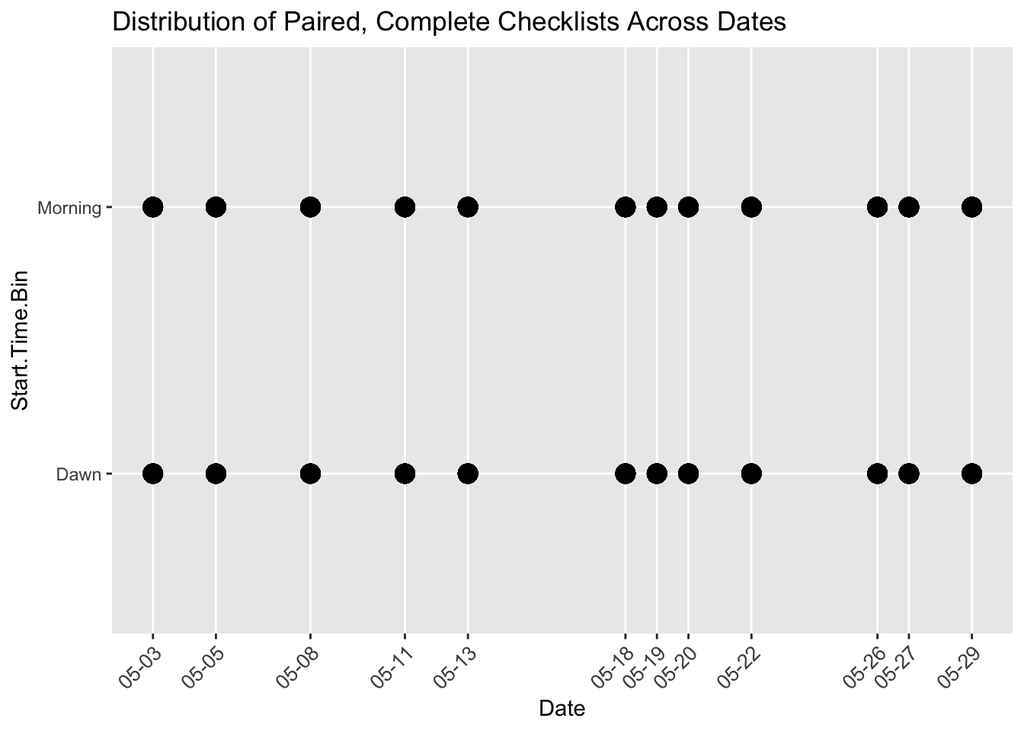

```r
# Graph representing the experiment dates
p_dates <- myebird_EXP %>%
  ggplot(aes(x=Date, y = Start.Time.Bin)) +
  geom_point(size = 4) +
  theme(axis.text.x = element_text(angle=45, size = 10, hjust=1),
          panel.grid.minor = element_blank()) +
  scale_x_date(breaks = sort(unique(myebird_EXP$Date)),
               date_labels = "%m-%d")+
  labs(title = "Distribution of Paired, Complete Checklists Across Dates")

p_dates
```

```r
ggsave(file.path(fig_dir, "Experiment Dates.png"),
             p_dates, width = 11, height = 7, dpi = 150)
```

## IV. D. Birdcast Migration Data

### IV. D.1 Migration Data: Make lists, dfs, and lines

```r
# ---- WAVE BOUNDS: single source of truth for the 5 migration waves ----
# Every band/rectangle drawn later (on the "Day of May" x-axis used by
# BirdCast, and on the "day of year" x-axis used by everything else) is
# derived from this one table, so a wave's date range only ever needs to
# be edited in one place. (assign_wave(), further down in section IV.G,
# encodes the same 5 waves for per-day lookup and should be kept in sync
# if these ranges change.)
wave_bounds <- tribble(
  ~Wave,     ~xmin, ~xmax,
  "Wave 1",   4.6,   6.4,
  "Wave 2",  10.6,  11.4,
  "Wave 3",  12.6,  13.4,
  "Wave 4",  16.6,  19.4,
  "Wave 5",  25.6,  27.4
)

# Grey rectangles marking each wave, on the "Day of May" axis
band_peaks <- pmap(wave_bounds, function(Wave, xmin, xmax) {
  annotate("rect", xmin = xmin, xmax = xmax, ymin = -Inf, ymax = Inf,
           fill = "grey50", alpha = 0.2)
})

# Same bands, shifted onto "day of year" (yday) coordinates -- used by every
# plot below that isn't on BirdCast's own "Day of May" axis.
may_offset <- yday(as.Date("2026-05-01")) - 1
wave_bands <- pmap(wave_bounds, function(Wave, xmin, xmax) {
  annotate("rect", xmin = xmin + may_offset, xmax = xmax + may_offset,
           ymin = -Inf, ymax = Inf, fill = "grey50", alpha = 0.2)
})

# Add Column Documenting Wave #
birdcast <- birdcast %>% mutate(
  Wave = factor(
    case_when(
#      Day.of.May == 1 ~ "Wave 1",
      Day.of.May == 5 | Day.of.May == 6 ~ "Wave 1",
      Day.of.May == 11 ~ "Wave 2",
      Day.of.May == 13 ~ "Wave 3",
      Day.of.May == 17 | Day.of.May == 18 | Day.of.May == 19 ~ "Wave 4",
      Day.of.May == 26 | Day.of.May == 27 ~ "Wave 5",
      .default = "No Wave"),
    levels = c("Wave 1", "Wave 2", "Wave 3", "Wave 4", "Wave 5", "Wave 6", "No Wave"),
    ordered = TRUE)
)
birdcast <- birdcast %>%
  mutate(yday = Day.of.May + (yday(as.Date("2026-05-01")) - 1))
```

### IV. D.2 Migration Data: Graphing

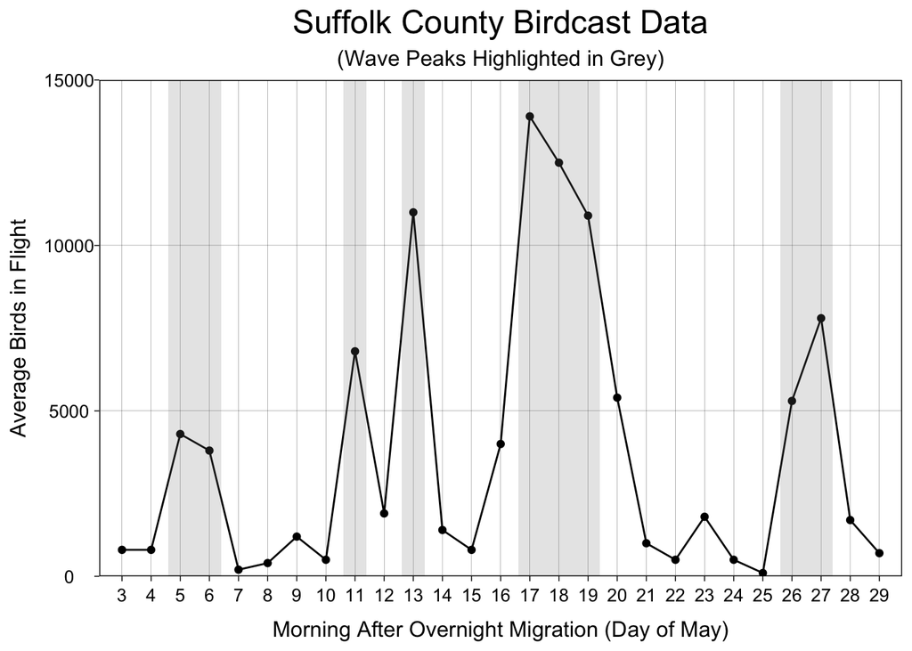

```r
title_size <- 18
subtitle_size <- 12
axis_title_size <- 12
axis_text_size <- 10
# Line graph Avg Migration
p_birdcast <-
birdcast %>% filter(Day.of.May >=3 & Day.of.May <=29) %>%
                ggplot(aes(x=Day.of.May, y = Average.Birds.in.Flight))+
                geom_point() +
                geom_line()+
                band_peaks +
                theme_linedraw() +
                labs(title = "Suffolk County Birdcast Data",
                                    subtitle = "(Wave Peaks Highlighted in Grey)",
                                    x = "Morning After Overnight Migration (Day of May)",
                                    y = "Average Birds in Flight") +
                scale_x_continuous(breaks = seq(3,29,1),
                                    expand = expansion(mult = c(0.03,0.03)))+
# Scale for patchworking
                scale_y_continuous(limits = c(0,15000),
                                   breaks = seq(0,15000,5000),
                                   expand = expansion(mult= c(0,0)))+
                theme(plot.title = element_text(hjust = 0.5, size = title_size),
                      plot.subtitle = element_text(hjust = 0.5, size = subtitle_size),

                      axis.title.x=element_text(size = axis_title_size),
                      axis.text.x = element_text(size = axis_text_size, margin=margin(b=6, t=4), hjust = 0.5),

                      axis.title.y = element_text(size =axis_title_size),
                      axis.text.y = element_text(size = axis_text_size, margin = margin(l=5),hjust = 0.5),
                      panel.grid.minor = element_blank())

p_birdcast
```

```r
ggsave(file.path(fig_dir, "Radar-Measured Nightly Migration.png"),
             p_birdcast, width = 11, height = 7, dpi = 150)
```

## IV. E. Observations: Heatmaps and Ridgeplots

### IV.E.1. All Species

A psuedolog transformation of the color scale is used, along with custom breaks, because a few species have very high counts

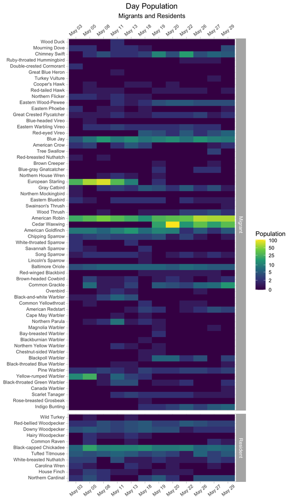

```r
# ALL Observations in Heat map, divided into Migrants and Residents
myebird_EXP_grouped <- myebird_EXP %>%
  left_join(my_tax_EXP %>% select(Species, Resident), by = "Species") %>%
  mutate(Resident = factor(Resident, levels = c(FALSE, TRUE), labels = c("Migrant", "Resident")))

myebird_EXP_grouped %>%
  ggplot(aes(x = Month.Day, y = Species, fill = Population)) +
  heatmap_theme +
   labs(title = "Day Population",
       subtitle = "Migrants and Residents",
    #   x = "Date",
       y = NULL) +
  facet_grid(rows = vars(Resident), scales = "free_y", space = "free_y") +
  scale_fill_viridis_c(breaks = c(0,2,5,10,25,50,100), trans = "pseudo_log")+
 scale_x_discrete(sec.axis = dup_axis())+
  theme(axis.text.x.bottom = element_text(size=8, angle = 40, vjust = 0.6),
        axis.text.x.top = element_text(size=8, angle = 40, vjust = 0.4),
        axis.text.y = element_text(size = 8, vjust = 0.3))
```

```r
ggsave(file.path(fig_dir, "Heatmap of All Species Observed.png"),
             p_dates, width = 11, height = 7, dpi = 150)
```

### IV.E.5. Warblers: Heatmaps; Ridges

#### IV.E.5.i. Warbler Heatmaps

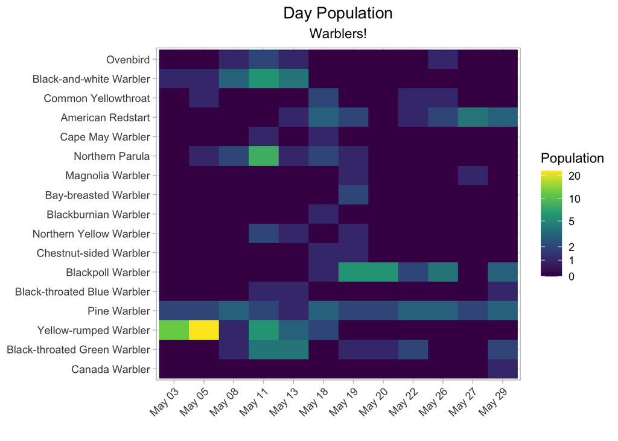

```r
# All Warblers
warblers %>%
ggplot(aes(x=Month.Day, y = Species, fill = Population))+
  heatmap_theme +
  labs(title = "Day Population",
       subtitle = "Warblers!",
       x = "",
       y = NULL) +
  scale_fill_viridis_c(breaks = c(0,1, 2, 5,10,20),trans = "pseudo_log") +
  theme(axis.text.x = element_text(angle = 45, hjust = 1),
  axis.text.x.top = element_text(margin = margin(b=4), hjust = 0))
```

```r
ggsave(file.path(fig_dir, "Heatmap of Warblers Observed.png"),
             p_dates, width = 11, height = 7, dpi = 150)
```

#### IV.E.5.ii Warbler Ridges

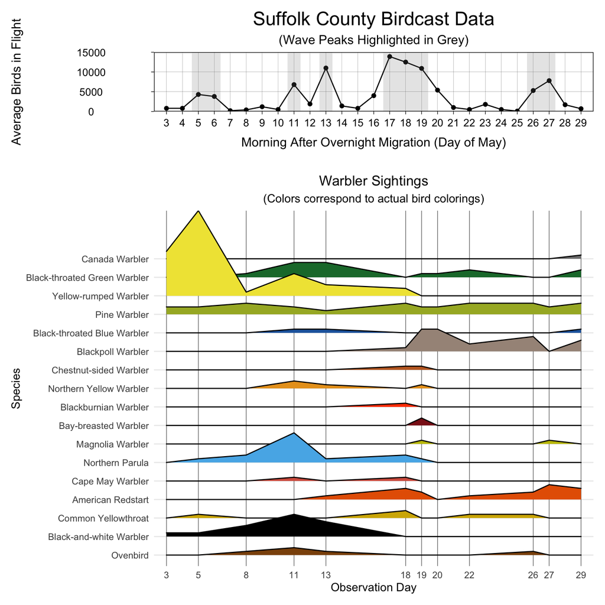

```r
# All warblers
p_warbs_ridges<- my_filter(warblers) %>%
                            ggplot(aes(x=Day, y = Species, height = Population, fill = Species))+
                            geom_ridgeline(scale = 0.2) +
                            scale_fill_manual(values = warbler_colors) +
                           # band_peaks +
                            theme_minimal() +
                            scale_x_continuous(breaks = obs_dates,
                                               expand = expansion(mult = c(0.03,0.03)),
                                               limits = c(3,29)) +
                            labs(title = "\nWarbler Sightings",
                            subtitle = "(Colors correspond to actual bird colorings)",
                              x="Observation Day")+
                            theme(legend.position = "none",
                            plot.title = element_text(hjust = 0.5),
                            plot.subtitle = element_text(hjust = 0.5),
                                  panel.grid.major.x = element_line(color = "gray50", linewidth = 0.3),
                                  axis.ticks.minor.x = element_blank(),
                                  panel.grid.minor.x = element_blank(),
                                  axis.ticks.major.y = element_blank())

p_birdcast / p_warbs_ridges + plot_layout(heights = c(1,6))
```

```r
ggsave(file.path(fig_dir, "Warbler Ridge Graphs.png"),
             p_dates, width = 11, height = 7, dpi = 150)
```

#### IV.E.5.iii Warbler DISCRETE Bar Graphs (technically more accurate than ridges)

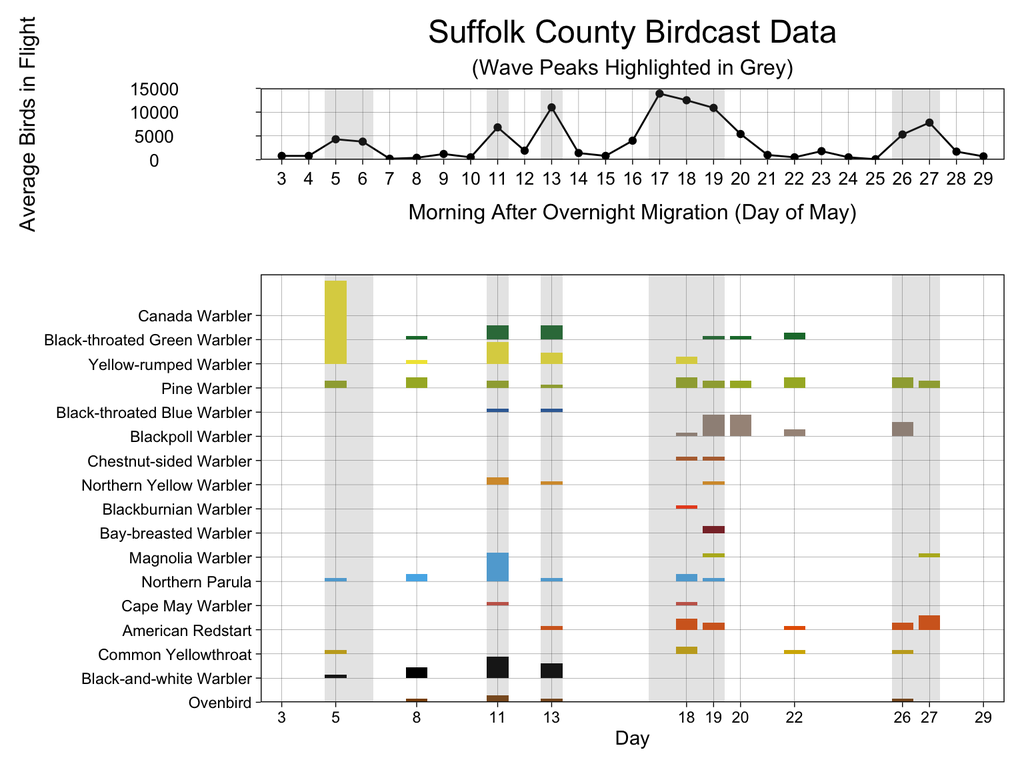

```r
# ALL WARBLERS

# STAGGERED BARS -- Use geom_rect so it can be merged like the ridgelines

# Give each species a numeric baseline position ####
warblers <- warblers %>%
    mutate(Species.Num = as.numeric(factor(Species)))

# GRAPHING
# Plot the Data ####
p_warbs_bars <- warblers %>%
    ggplot(aes(x = Day, y = Species.Num)) +
    geom_rect(aes(xmin = Day - 0.4, xmax = Day + 0.4,
                  ymin = Species.Num, ymax = Species.Num + Population * 0.15,
                  fill = Species)) +
# Theme and aesthetics ####
    theme_linedraw() +
    scale_fill_manual(values = warbler_colors)+
    band_peaks+
    labs(title = "",
         y = "")+
# Axes ####
    scale_x_continuous(
      limits = c(3,29),
      breaks = obs_dates,
      expand = expansion(mult= c(0.03,0.03))) +
    scale_y_continuous(
      breaks = sort(unique(warblers$Species.Num)),
      labels = levels(factor(warblers$Species)),
      expand = expansion(mult = c(0,0))) +
  # Use coord_cart instead of scale_y_cont(limits = ) so that geom_rect doesn't drop any bars if they go off the chart!
    coord_cartesian(ylim = c(1,18.7))+
    theme(legend.position = "none",
         # panel.grid.major = seq(1,31,7),
          panel.grid.minor = element_blank())

p_birdcast / p_warbs_bars + plot_layout(heights= c(1,6))
```

```r
ggsave(file.path(fig_dir, "Warbler Ridge Graphs.png"),
             p_dates, width = 11, height = 7, dpi = 150)
```

### IV.D.6. 18 Favorites: Ridges; Ridges+ Birdcast Merged PLot

#### IV.D.6.i. Ridges plot alone

```r
# Make Ridges plot
p_good_patterns_ridges <- good_patterns %>%
                            ggplot(aes(x=Day, y = Species, height = Population, fill = Species))+
                            geom_ridgeline(scale = 0.15) +
                           # scale_fill_manual(values = warbler_colors) +
                           # band_peaks +
                            theme_minimal() +
                            scale_x_continuous(breaks = obs_dates,
                                               expand = expansion(mult = c(0.03,0.03)),
                                               limits = c(3,29)) +
                            coord_cartesian(ylim = c(1.3, 17.4)) +
                            labs(title = "Favorite Birds, Clear Patterns",
                                 #subtitle = "",
                                 y = NULL,
                                 x="Observation Day") +
                            theme(legend.position = "none",
                                  plot.title = element_text(hjust = 0.5),
                                  panel.grid.major.x = element_line(color = "gray50", linewidth = 0.3),
                                  panel.grid.major.y = element_line(color = "gray0", linewidth = 0.3),
                               #  axis.ticks.major.y = element_blank()) +  # not defined in element hierarcy error
                                #  axis.ticks.minor.x = element_blank(),  # not defined in element hierarcy error
                                  panel.grid.minor.x = element_blank())
```

#### IV.D.6.ii. Ridges + Birdcast Merged Plot

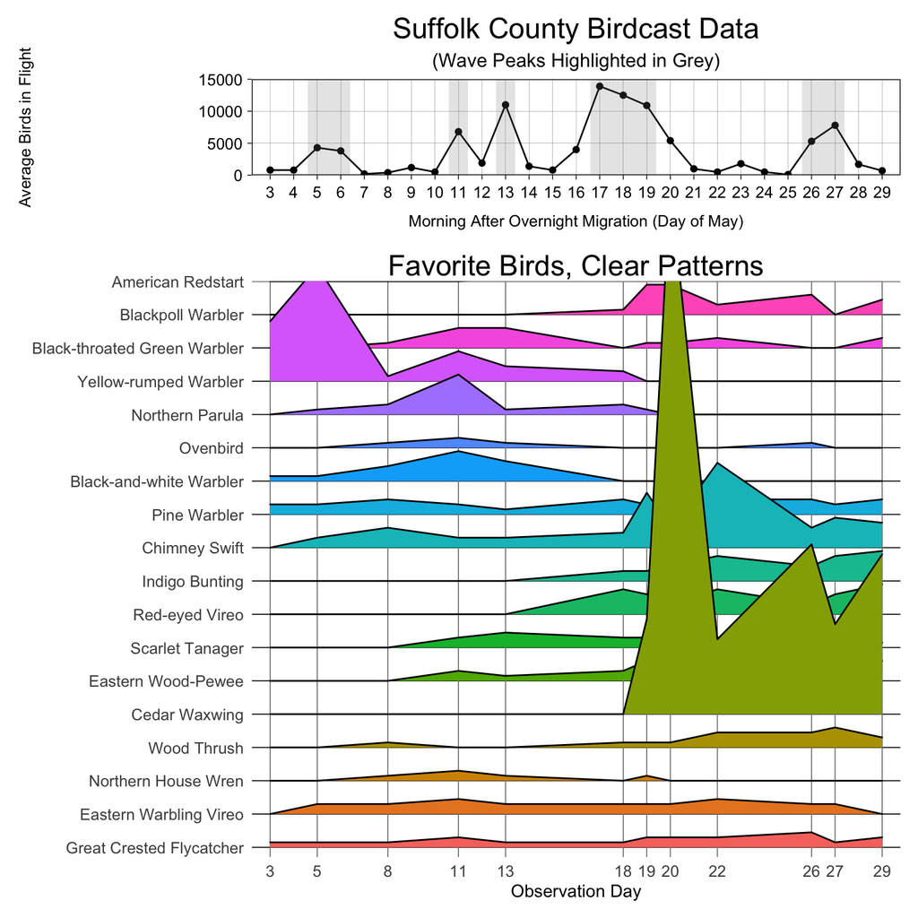

```r
# Re-set graph sizes for this merged figure specifically (smaller
# axis_title_size/axis_text_size than the standalone BirdCast plot above,
# since this version gets squeezed into a shared panel with the ridgeline).
title_size <- 18
subtitle_size <- 12
axis_title_size <-10
axis_text_size <-10

# Make Birdcast portion of plot
p_birdcast_large <-  p_birdcast +
  theme(
    axis.title.y = element_text(size = axis_title_size, margin = margin(r = 0),vjust = 0.5),
    axis.text.y  = element_text(size = axis_text_size,  hjust = 1, margin = margin(r=3,l=0)),
    axis.title.x = element_text(size = axis_title_size)
                                )

# Make Ridges portion of plot
p_good_patterns_ridges_large <-
  p_good_patterns_ridges +
  theme(plot.title = element_text(size=title_size, margin = margin(t=5)),
        axis.text.x = element_text(size=axis_text_size),
        axis.text.y = element_text(size=axis_text_size))

# Print plot
p_birdcast_large / p_good_patterns_ridges_large + plot_layout(heights = c(1,6))
```

## IV. F. 3-panel figures

### IV. F.1. Download Expected Species Data (Abundance from)

```r
# ---- CALL MAP_DFR TO DOWNLOAD SPECIES DATA-- all 18 species ----
# Checks if it's already been downloaded
# Saves new RDS ONLY ONCE, expected_all and exp_path
good_patterns_sp <- levels(good_patterns$Species)

# Relative to this .Rmd's own folder (same convention as the readRDS() calls
# in Setup), so it still works no matter whose computer this project is on.
exp_path <- "./data/expected_all.rds"

if (file.exists(exp_path)) {
  expected_all <- readRDS(exp_path)
} else {
  expected_all <- map_dfr(good_patterns_sp, get_expected_abundance)
  saveRDS(expected_all, exp_path)
}
```